# DATA 607 Tidy Verse assignment

Yohannes Deboch

February 24, 2019

# 1.Create an Example.Using one or more TidyVerse packages, and any dataset from fivethirtyeight.com or Kaggle, create a programming sample “vignette” that demonstrates how to use one or more of the capabilities of the selected TidyVerse package with your selected dataset.

## Load the library

```r
library(tidyverse)
```

## Data source

https://www.kaggle.com/ronitf/heart-disease-uci

## Read the data using readr

`r disease <- read_csv("heart.csv")`

`## Parsed with column specification: ## cols( ## age = col_double(), ## sex = col_double(), ## cp = col_double(), ## trestbps = col_double(), ## chol = col_double(), ## fbs = col_double(), ## restecg = col_double(), ## thalach = col_double(), ## exang = col_double(), ## oldpeak = col_double(), ## slope = col_double(), ## ca = col_double(), ## thal = col_double(), ## target = col_double() ## )`

`r head(disease)`

`## # A tibble: 6 x 14 ## age sex cp trestbps chol fbs restecg thalach exang oldpeak ## <dbl> <dbl> <dbl> <dbl> <dbl> <dbl> <dbl> <dbl> <dbl> <dbl> ## 1 63 1 3 145 233 1 0 150 0 2.3 ## 2 37 1 2 130 250 0 1 187 0 3.5 ## 3 41 0 1 130 204 0 0 172 0 1.4 ## 4 56 1 1 120 236 0 1 178 0 0.8 ## 5 57 0 0 120 354 0 1 163 1 0.6 ## 6 57 1 0 140 192 0 1 148 0 0.4 ## # … with 4 more variables: slope <dbl>, ca <dbl>, thal <dbl>, target <dbl>`

The selected package I want to use id dplyr.

## Capability 1.

### filter capability tutorial

### Description

Using filter we can select rows of the data frame matching conditions.

### Usage filter(data) ### Example

To select the people of over 20 and less than 65 we can pass the data disease and condtion age>20 and age < 65 to the function . It’ll return matching rows of heart disease.

`r filter(disease, age>20 & age < 65)`

`## # A tibble: 262 x 14 ## age sex cp trestbps chol fbs restecg thalach exang oldpeak ## <dbl> <dbl> <dbl> <dbl> <dbl> <dbl> <dbl> <dbl> <dbl> <dbl> ## 1 63 1 3 145 233 1 0 150 0 2.3 ## 2 37 1 2 130 250 0 1 187 0 3.5 ## 3 41 0 1 130 204 0 0 172 0 1.4 ## 4 56 1 1 120 236 0 1 178 0 0.8 ## 5 57 0 0 120 354 0 1 163 1 0.6 ## 6 57 1 0 140 192 0 1 148 0 0.4 ## 7 56 0 1 140 294 0 0 153 0 1.3 ## 8 44 1 1 120 263 0 1 173 0 0 ## 9 52 1 2 172 199 1 1 162 0 0.5 ## 10 57 1 2 150 168 0 1 174 0 1.6 ## # … with 252 more rows, and 4 more variables: slope <dbl>, ca <dbl>, ## # thal <dbl>, target <dbl>`

## Capability 2.

### select capability tutorial

###Description

Using select we can keep the selected variables

###sage select(data, …)

###Example

To keep only age, sex,cp variable we can pass the data disease and age, sex,cp to the function .

`r df<- select(disease, c("age","sex","cp")) head(df)`

`## # A tibble: 6 x 3 ## age sex cp ## <dbl> <dbl> <dbl> ## 1 63 1 3 ## 2 37 1 2 ## 3 41 0 1 ## 4 56 1 1 ## 5 57 0 0 ## 6 57 1 0`

## Extended by Santosh Cheruku ### Using dplyr::Arrange - To change the ordering of rows

### Description

Using arrange we can order the rows in an expression involving variables

### Example To arrange the rows by sex and age

```r
df <- df %>% arrange(sex, age)
head(df)
```

```
## # A tibble: 6 x 3
##     age   sex    cp
##   <dbl> <dbl> <dbl>
## 1    34     0     1
## 2    35     0     0
## 3    37     0     2
## 4    39     0     2
## 5    39     0     2
## 6    41     0     1
```

```r
tail(df)
```

```
## # A tibble: 6 x 3
##     age   sex    cp
##   <dbl> <dbl> <dbl>
## 1    69     1     2
## 2    70     1     1
## 3    70     1     0
## 4    70     1     0
## 5    70     1     2
## 6    77     1     0
```

## Extended by - Suma Gopal:

### Addition of ggplots2 package

We can use ggplot() to visualize the data, by supplying the ggplot() with the data, aesthetics, and mapping accordingly to the variables. * We can use ggplot2() to plot a bubble chart of cholesterol vs. age. The size of the points get larger as cholesterol increases. We do this by setting the size property of aesthetic to the cholesterol variable.

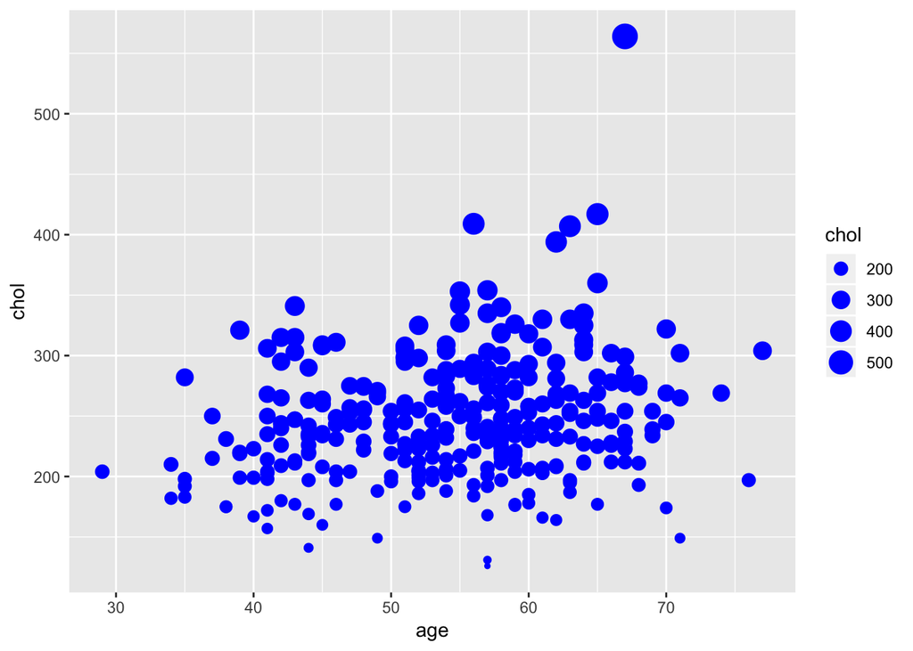

```r
  library(ggplot2)
  ggplot(disease, aes(age, chol)) + geom_point(aes(size = chol), colour = "blue")
```

- We can view chest pain type by age by setting stat to “identity.” We use a bar graph by using gemo_bar():

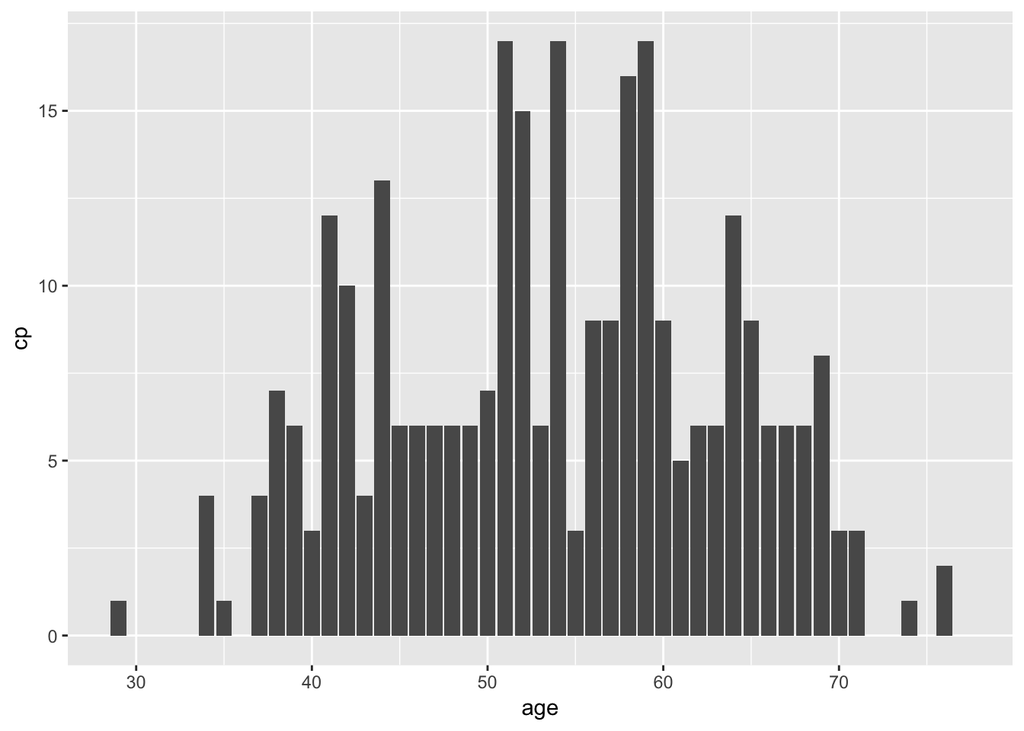

```r
  ggplot(data = df) + geom_bar(mapping = aes(x = age, y = cp), stat = "identity")
```

- We can also apply jittered points to add random variation to the location of each point caused by discreteness in smaller datasets. Here we can see jittered points for chest pain vs. age. They colored by chest pain type.

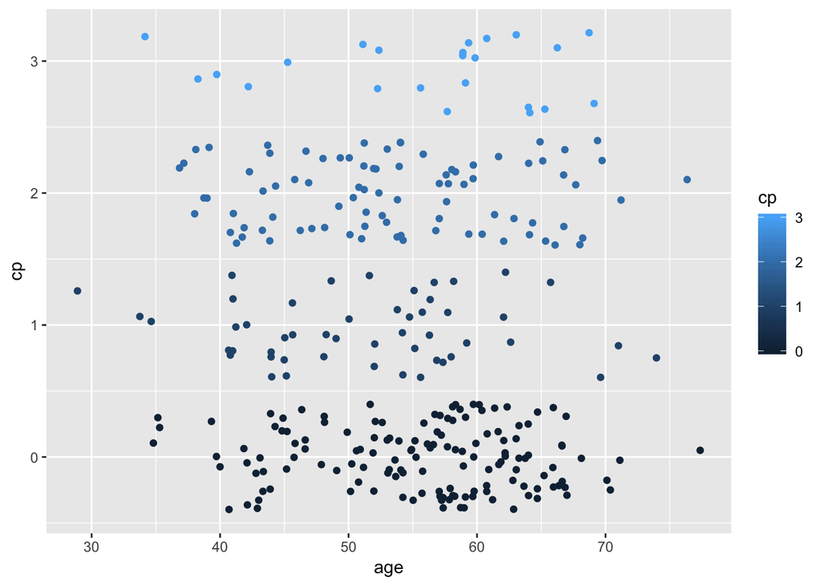

```r
ggplot(df, aes(age, cp)) + geom_jitter(aes(colour = cp))
```